# Python Workshop Week 1: Building Blocks

Katy Brown

kab84@cam.ac.uk

```python
from IPython.display import Image
```

There are three main ways to use Python:

- Jupyter Notebook
- Interactive Mode
- Scripts

I will introduce one of these every week - this week we will only use this Jupyter notebook.

## Jupyter Notebook

In Jupyter notebook you can type in a mixture of free text and Python.

In the dropdown box at the top

- If you choose **Markdown** you can type anything and it will be interpreted as text, you can also add small amounts of formatting, like **bold** and *italics*.
- If you choose **Code** you can type and run Python code.
- **Heading** produces larger text for headings
- **Raw NBConvert** is plain text

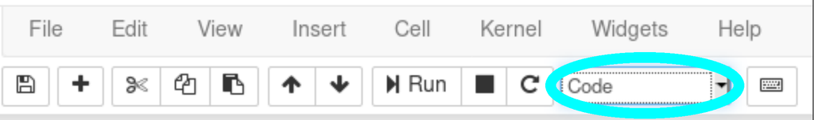

```python
Image('screenshot1.png')
```

To run the contents of a **Code** cell, either click on "Run" in the toolbar or press Ctrl+Enter

Try running the cell below.

```python
print("This is Python")
```

```
This is Python
```

In a **Code** cell, any text which follows a hash symbol (#) is not evaluated by Python.

This can be used to annotate your code with comments.

```python
# This is a comment - you can run this code cell and nothing will happen
```

## Functions

In programming, **functions** are used to carry out actions on data.

A function tells Python to do something. It acts like a verb in your program - it tells Python which action to perform.

Here is your first Python program. Run it by clicking Run or pressing Ctrl+Enter.

```python
print("Hello, world!")
```

```
Hello, world!
```

`print` is a function

The `print` function tells Python to print some text to the screen.

```python
print("You can change the text to anything you like")
```

```
You can change the text to anything you like
```

There are hundreds of functions in Python, here are some examples (you don't need to remember them yet).

The `list` function converts text into a list of characters.

```python
list("Hello")
```

```
['H', 'e', 'l', 'l', 'o']
```

The `sum` function adds together a list of numbers.

```python
sum([1, 2, 3, 4])
```

```
10
```

The `len` function tells you how many items are in a list or how long a character string is.

```python
len([1, 2, 3, 4])
```

```
4
```

**Exercise**

Create your own tiny program using the `print` statement in the cell below.

**Exercise**

Run the following functions and see if you can figure out what they do.

```python
max([3, 7, 1, 2])
```

```
7
```

```python
sorted([3, 7, 1, 2])
```

```
[1, 2, 3, 7]
```

```python
abs(-10)
```

```
10
```

In Jupyter, if you type a function name then press Shift+TAB you can see the beginning of the help page for that function. If you press it twice you will see more information.

**Exercise**

Try this with the functions from the previous exercise.

## Variables

### What is a variable?

As well as functions, programmers use **variables** in their code.

A variable is a value, which can be changed, which is referred to by a name in your program.

You can **assign** a variable to a name using the `=` symbol

```python
x = 500
```

You can then **pass** the variable to a function in order to perform an action on the variable. Here we will pass `x` to the `print` function.

```python
print(x)
```

```
500
```

Once you have assigned the variable to this name it will **keep the same value** until you either restart Python or change the value.

```python
print(x)
```

```
500
```

```python
x = 1000
```

```python
print(x)
```

```
1000
```

In Jupyter, if you run the cells in the wrong order the value of the variable may not change as you expect.

Try running the following cell (`x = 250`) now and then running the cell above (`print (x)`) again.

```python
x = 250
```

You can have as many variables as you like and give them any name you choose with the following exceptions:

- the name can't start with a number (it can have numbers in it elsewhere)
- the name can't contain spaces
- the name can't contain quotation marks

```python
hello = 100
im_a_variable = "v"
variable1 = 0.234
```

```python
print(hello)
```

```
100
```

```python
print(im_a_variable)
```

```
v
```

```python
print(variable1)
```

```
0.234
```

**Exercise**

Create a variable with `my_variable` as the name and the word "VARIABLE" as the value.

Hint: *the word VARIABLE should be in quotation marks*

**Exercise**

Print your variable below using the `print` function.

After running a function on a variable, you can assign the output of the function to a new variable.

For example, here we create a variable `variable1` then apply the `list` function to it, assigning the output of the function to a new variable `variable2`.

```python
variable1 = "hello"
variable2 = list(variable1)
```

```python
print(variable1)
```

```
hello
```

```python
print(variable2)
```

```
['h', 'e', 'l', 'l', 'o']
```

Here we create a variable `a_few_numbers`, add them together using the `sum` function and assign the output to a new variable `sum_of_a_few_numbers`.

```python
a_few_numbers = [1, 5, 6]
sum_of_a_few_numbers = sum(a_few_numbers)
```

```python
a_few_numbers
```

```
[1, 5, 6]
```

```python
sum_of_a_few_numbers
```

```
12
```

**Exercise**

Using the `len` function you can find out the length of a variable.

Run the `len` function on `my_variable` created above and store the output as `my_new_variable`. Then print the contents of `my_new_variable`.

### Types of Variable

There are many different types of variable in Python. The basic types are:

**Variables with a single value**

- String
- Integer
- Float
- Boolean

**Variables with a sequence of values**

- List
- Tuple
- Dictionary

Python tries to determine automatically which type of variable you have created and use it correctly, usually it gets this right.

You can find out what type of variable you are using with the `type` function.

```python
x = "hello"
type(x)
```

```
str
```

```python
x = 10
type(x)
```

```
int
```

```python
x = 0.5
type(x)
```

```
float
```

```python
x = True
type(x)
```

```
bool
```

```python
x = [1, 2, 3]
type(x)
```

```
list
```

```python
x = {"x": 1, "y": 2}
type(x)
```

```
dict
```

**Exercise**

Find out the type of the following variables.

```python
v1 = 100
v2 = 0.05
v3 = "some text"
v4 = ['a', 'b', 'c', 'd']
```

### Strings (`str`)

A string consists of one piece of text - a sequence of characters. It could be a word or a sentence.

It can contain spaces and numbers, but any numbers will be treated as text by Python - you won't be able to use them in mathematical operations.

Strings should always be in quotation marks.

It doesn't matter if you use double quotes `""` or single quotes `''` as long as you use the same at either end of your string

```python
astring1 = 'Hello, I am a string'
```

```python
print(astring1)
```

```
Hello, I am a string
```

```python
type(astring1)
```

```
str
```

```python
another_string = "ThisIsAlsoAString"
```

```python
print(another_string)
```

```
ThisIsAlsoAString
```

```python
type(another_string)
```

```
str
```

```python
string_with_numbers = "There is 1 number in this string"
```

```python
print(string_with_numbers)
```

```
There is 1 number in this string
```

```python
type(string_with_numbers)
```

```
str
```

Remember, it doesn't matter what you name your variables.

### Integers (`int`)

An integer is a positive or negative whole number, which is not a fraction.

If you pass Python a whole number, not in quotation marks, it will assume it is an integer.

```python
integer1 = 1
```

```python
print(integer1)
```

```
1
```

```python
type(integer1)
```

```
int
```

```python
integer2 = 50
```

```python
print(integer2)
```

```
50
```

```python
type(integer2)
```

```
int
```

```python
integer3 = -10
```

```python
print(integer3)
```

```
-10
```

```python
type(integer3)
```

```
int
```

### Floats (`float`)

A float represents a "floating point number", aka a number with a decimal point.

If you pass Python a number with a decimal point in it, it will assume it is a float.

```python
float1 = 0.1
```

```python
print(float1)
```

```
0.1
```

```python
type(float1)
```

```
float
```

```python
float2 = 1.0
```

```python
print(float2)
```

```
1.0
```

```python
type(float2)
```

```
float
```

### Booleans (`bool`)

Boolean variables can be True or False.

```python
i_am_true = True
```

```python
print(i_am_true)
```

```
True
```

```python
type(i_am_true)
```

```
bool
```

```python
i_am_false = False
```

```python
print(i_am_false)
```

```
False
```

```python
type(i_am_false)
```

```
bool
```

We will learn more about using booleans later.

**Exercise**

Assign four variables - a string, an integer, a float and a boolean.

### Lists (`list`)

Now we are moving on to variables which contain a sequence of values.

The simplest of these is a list.

We define a list by providing a sequence of values, seperated by commas, in square brackets `[]`.

```python
mylist = [1, 2, 3]
```

```python
print(mylist)
```

```
[1, 2, 3]
```

```python
type(mylist)
```

```
list
```

The items in the list will always stay in their original order, unless we specifically change them.

The items in the list can consist of any other type of variable.

```python
mixed_list = [1, "cat", 0.005, "pigeon"]
```

```python
print(mixed_list)
```

```
[1, 'cat', 0.005, 'pigeon']
```

```python
type(mixed_list)
```

```
list
```

Each item in a list has an **index** which refers to its position in the list (1st item, 2nd item etc.)

In Python we count from 0 rather than 1.

To extract a single item from the list we can use its index.

```python
mixed_list = [1, "cat", 0.005, True]
```

```python
print(mixed_list[0])
```

```
1
```

```python
print(mixed_list[1])
```

```
cat
```

```python
print(mixed_list[2])
```

```
0.005
```

```python
print(mixed_list[3])
```

```
True
```

Each of the items in the list also has a type.

```python
type(mixed_list[0])
```

```
int
```

```python
type(mixed_list[1])
```

```
str
```

```python
type(mixed_list[2])
```

```
float
```

```python
type(mixed_list[3])
```

```
bool
```

Lists are **mutable** - we can add or remove items from a list or rearrange them after it has been created.

We can add items to the end of a list using the `append` method.

```python
mixed_list.append('abcde')
```

```python
print (mixed_list)
```

```
[1, 'cat', 0.005, True, 'abcde']
```

We can remove items from the end of a list using the `pop` method. The item which has been removed will be shown.

```python
mixed_list.pop()
```

```
'abcde'
```

```python
mixed_list
```

```
[1, 'cat', 0.005, True]
```

You can also put variables you have already assigned into a list.

```python
x = 1
y = 2
z = "hi"

this_list = [x, y, z]
```

```python
print(this_list)
```

```
[1, 2, 'hi']
```

```python
type(this_list)
```

```
list
```

```python
print(this_list[0])
```

```
1
```

```python
type(this_list[0])
```

```
int
```

```python
print(this_list[2])
```

```
hi
```

```python
type(this_list[2])
```

```
str
```

```python
a = 0.024
this_list.append(a)
```

```python
print(this_list)
```

```
[1, 2, 'hi', 0.024]
```

**Exercise**

Make a list with at least 4 items containing a mixture of floats, integers, booleans and strings.

Extract the 1st and 4th items from the list (index 0 and index 3)

Append an item to the end of the list, then remove it.

### Tuples (`tuple`)

A tuple is similar to a list, except that it is **not mutable** - once it has been created you can't change anything inside it.

A tuple still contains a sequence of values, which can be a mixture of different types.

A tuple is defined using a sequence of items, seperated by commas and surrounded by two pairs of round brackets `(())`

```python
t1 = ((1, 'banana', False))
```

```python
print (t1)
```

```
(1, 'banana', False)
```

```python
type(t1)
```

```
tuple
```

Like a list, we can access items in a tuple using their index.

```python
print(t1[0])
```

```
1
```

```python
print(t1[1])
```

```
banana
```

```python
print(t1[2])
```

```
False
```

### Dictionaries (`dict`)

The final type of variable we will cover today is a dictionary. Dictionaries are very useful in Python code.

In a dictionary, rather than having an ordered sequence of values, each value has a **key** - a name which is used to retrieve the value.

Dictionaries are defined using curly brackets `{}` containing pairs of keys and values seperated by commas.

Dictionary keys must be strings but the values can be any type of variable.

```python
my_dict = {'key1': 1, 'key2': 2, 'key3': 'another_value'}
```

```python
print (my_dict)
```

```
{'key1': 1, 'key2': 2, 'key3': 'another_value'}
```

Instead of using an index, we can use the key to retrieve items from a dictionary, by providing the name of the dictionary then the name of the key in square brackets.

```python
my_dict['key1']
```

```
1
```

```python
my_dict['key2']
```

```
2
```

```python
my_dict['key3']
```

```
'another_value'
```

Dictionary keys can be any string and the values can be any type of new variable or an existing variable.

```python
x = 0
dict_2 = {'ab': 123, 'xy': True, 'op': 0.1, 'vw': x}
```

```python
print(dict_2)
```

```
{'ab': 123, 'xy': True, 'op': 0.1, 'vw': 0}
```

```python
type(dict_2)
```

```
dict
```

```python
dict_2['ab']
```

```
123
```

```python
dict_2['xy']
```

```
True
```

```python
dict_2['op']
```

```
0.1
```

```python
dict_2['vw']
```

```
0
```

**Exercise**

Create a dictionary with three pairs of keys and values, using a mixture of variable types, then print each value individually and check its type.

## Basic Python Operations

We will now cover a couple of basic things you are likely to need to incorporate into your Python code.

### Arithmetic in Python

You can do basic maths in Python on integers and floats and assign the result to a new variable

```python
integer1 = 3
integer2 = 5
```

```python
addition_result = integer1 + integer2
```

```python
print (addition_result)
```

```
8
```

```python
subtraction_result = integer1 - integer2
```

```python
print (subtraction_result)
```

```
-2
```

```python
multiplication_result = integer1 * integer2
```

```python
print (multiplication_result)
```

```
15
```

```python
division_result = (integer1 / integer2)
```

```python
print (division_result)
```

```
0.6
```

You can also combine these operations.

```python
x = 1
y = 0.5
z = 1000

result = x * ((x + y) / z)
```

```python
print (result)
```

```
0.0015
```

There are a couple of other Python arthimetic operators you may need.

`**` is used for powers, e.g. `3**2` will return the value of three squared.

```python
print (5**2)
```

```
25
```

```python
print (2**3)
```

```
8
```

`%` is used to mean **modulo** or **remainder** - it returns the remainder when one value is divided by the other.

For example

9 / 2 = 4 remainder 1, so `9 % 2` = 1

```python
print (9 % 2)
```

```
1
```

11 / 3 = 3 remainder 2, so `11 % 3` = 2

```python
print (11 % 3)
```

```
2
```

**Exercise**

Create two integer variables and perform these six operations (addition, subtraction, multiplication, division, power and modulo) on them, assigning each result to a new variable.

### True or False Statements in Python

Finally, we are going learn how to ask Python a question with a True or False (or **boolean**) answer.

There are several different things we can do.

Because we use the `=` symbol to assign variables in Python, we can't use it to check if two values are equal. So, similarly to many other languages, we use two equals symbols `==`

To assign a value of 1 to `x` we use the `=` symbol

```python
x = 1
```

But to ask if `x` is equal to 1 we use the `==` symbol.

```python
print(x == 1) # is x equal to 1?
```

```
True
```

```python
print(x == 2) # is x equal to 2?
```

```
False
```

We can do also do this with two variables.

```python
x = 1
y = 2
```

```python
print(x == y) # is x equal to y?
```

```
False
```

We can invert this using the symbol `!=` to mean **is not equal to**.

```python
x = 6
y = 10
```

```python
print(x != y) # is x not equal to y?
```

```
True
```

```python
x = 1
y = 1
```

```python
print(x != y) # is x not equal to y?
```

```
False
```

These operators also work with strings and floats.

```python
print(0.1 == 0.2)
```

```
False
```

```python
print('text1' == 'text1')
```

```
True
```

```python
print('text1' != 2)
```

```
True
```

You can assign the outcome of one of these operators to another variable.

```python
x = 1
y = 2

v = x == y
```

```python
print(v)
```

```
False
```

```python
type(v)
```

```
bool
```

You can use more than `>`, less than `<`, more than or equal to `>=` and less than or equal to `<=` operators in a similar way.

```python
x = 1
y = 2
```

```python
print (x > y)
```

```
False
```

```python
print (y > x)
```

```
True
```

```python
x = 1
y = 1
```

```python
print (x > y)
```

```
False
```

```python
print (x >= y)
```

```
True
```

```python
print (x <= y)
```

```
True
```

Finally, you can use the terms `and` and `or` to combine these operators.

`and` means both statements are True

`or` means at least one statement is True

```python
x = 1
y = 2
```

```python
print(x == 1)
```

```
True
```

```python
print(y == 2)
```

```
True
```

```python
print(x == 1 and y == 2)
```

```
True
```

```python
print(x == 1 or y == 2)
```

```
True
```

```python
print(x == 0)
```

```
False
```

```python
print(x == 0 and y == 2)
```

```
False
```

```python
print(x == 0 or y == 2)
```

```
True
```

```python
print(y == 0)
```

```
False
```

**Exercise**

- Assign two variables, `variable1 = 10` and `variable2 = 20`.
- Print the variables
- Add the two variables together
- Write a True / False statement with one operator which is True
- Write a True / False statement with one operator which is False
- Write a True / False statement using `and` which is True
- Write a True / False statement using `or` which is True
- Write a True / False statement which is True using `or` but False using `and`

## Key Terms

| **Term** | **Definition** |
| --- | --- |
| **function** | An action you would like Python to perform |
| **variable** | A a value, which can be changed, which is referred to by a name in your program |
| **string** | One piece of text - a sequence of characters |
| **integer** | A positive or negative whole number, which is not a fraction |
| **float** | A "floating point number", aka a number with a decimal point |
| **boolean** | A True or False value |
| **mutable** | A variable with a value which can be altered after it has been created |
| **list** | An ordered sequence of values of any type which is mutable |
| **tuple** | An ordered sequence of values of any type which is not mutable |
| **dictionary** | An unordered set of pairs of keys and values, where the key (a string) is used to access the value |
| **index** | The position of an item in a sequence, with 0 as the first position |
| **modulo** | The "remainder" in a division operation |
| **and** | Tests if two statements are both True |
| **or** | Tests if either of two statements are True |

## Homework (optional)

Open a new Jupyter notebook and write your own short Python program.

In this program you should:

- Assign two variables, one integer and one float
- Print both variables
- Check the type of both variables
- Check if the variables are equal to each other
- Add the two variables together and assign this value to a new variable
- Print the new variable and check its type
- Make a list containing all three variables
- Print the list
- Generate a True and a False statement using `and`, `or` and your variables.

## Feedback

It would be really helpful if after each week you could fill out this (anonymous) form, so that I can make sure the course goes as smoothly as possible for everyone.

https://katybrown2.typeform.com/to/xz2Og3